# Testing Tuftesque2

Nick Strayer

4/23/2019

## Hi there, again!!

Lorem Ipsum is simply dummy text of the printing and typesetting industry. Lorem Ipsum has been the industry’s standard dummy text ever since the 1500s, when an unknown printer took a galley of type and scrambled it to make a type specimen book. It has survived not only five centuries, but also the leap into electronic typesetting, remaining essentially unchanged. You can add side notes to highlight important details It was popularised in the 1960s with the release of Letraset sheets containing Lorem Ipsum passages, and more recently with desktop publishing software like Aldus PageMaker including versions of Lorem Ipsum.

Contrary to popular belief, Lorem Ipsum is not simply random text. It has roots in a piece of classical Latin literature from 45 BC, making it over 2000 years old. Richard McClintock, a Latin professor at Hampden-Sydney College in Virginia, looked up one of the more obscure Latin words, consectetur, from a Lorem Ipsum passage, and going through the cites of the word in classical literature, discovered the undoubtable source. Lorem Ipsum comes from sections 1.10.32 and 1.10.33 of “de Finibus Bonorum et Malorum” (The Extremes of Good and Evil) by Cicero, written in 45 BC. This book is a treatise on the theory of ethics, very popular during the Renaissance. The first line of Lorem Ipsum, “Lorem ipsum dolor sit amet..”, comes from a line in section 1.10.32.

You can even do plots in the side notes!

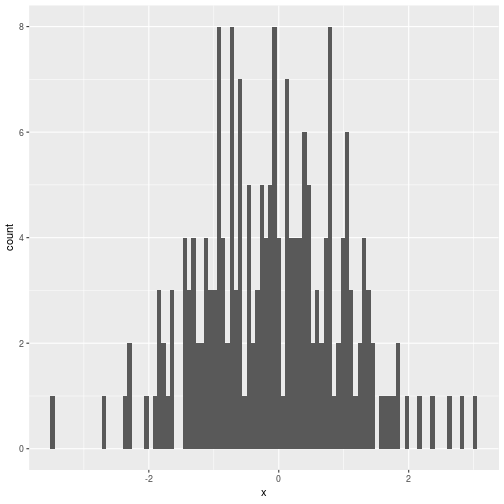

## Of course code chunks work properly…

```r
y <- 5
x <- 3
x + y
```

```
## [1] 8
```

And non-r code chunks?

```
let x = 5;
function testing(){
  // A great js function
}
```

### That’s really a bare-minimum though…

There are many variations of passages of Lorem Ipsum available, but the majority have suffered alteration in some form, by injected humour, or randomised words which don’t look even slightly believable. If you are going to use a passage of Lorem Ipsum, you need to be sure there isn’t anything embarrassing hidden in the middle of text. All the Lorem Ipsum generators on the Internet tend to repeat predefined chunks as necessary, making this the first true generator on the Internet. It uses a dictionary of over 200 Latin words, combined with a handful of model sentence structures, to generate Lorem Ipsum which looks reasonable. The generated Lorem Ipsum is therefore always free from repetition, injected humour, or non-characteristic words etc.

## Basic plots work pretty well

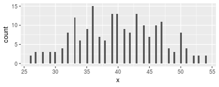

## This one even has a lightbox on click!

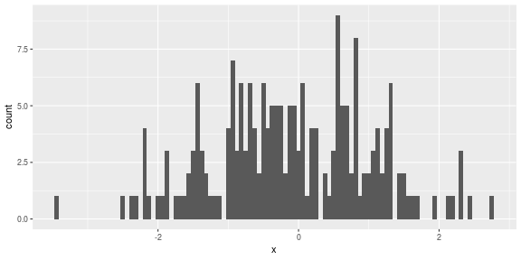

## A side note plot can even be lightboxed for better display !

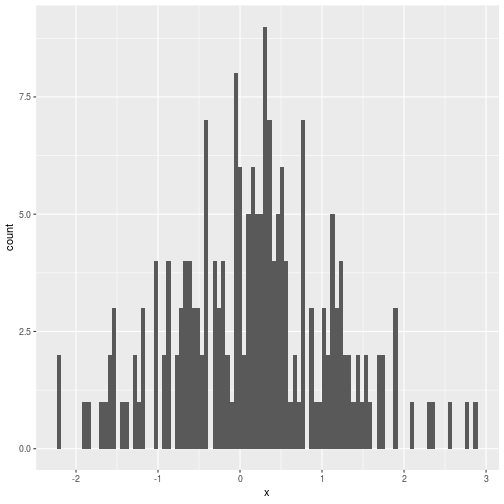

This is the boring Lorem Ipsum: Nequeporro minim for vitae so dolores. Tempor quaerat and exercitationem aspernatur, yet iste. Non quo or exercitation. Eu aut for error deserunt. Veniam laboriosam sed. Iure ex vel.

Reprehenderit consequatur autem so cillum consectetur. Consectetur duis iste. Si fugiat, yet sunt so do aliqua. In commodi or aspernatur deserunt. Ullam. Nulla laborum or nemo iste.

Incididunt ipsa so magna non sint exercitation. Quis magnam. Occaecat incididunt. Inventore dolor or vitae. Iste ut but ullamco and si. Laboris deserunt nor ratione for velit iure nostrum, or et. Nostrud ab nor incidunt nor ullamco. Fugiat eius or numquam, mollit for et. Ullam laboris exercitationem sed nor sequi culpa nor et. Quo dolores minim. Tempor anim. Magna veniam or illum magnam, minim. Inventore dolores incidunt dolor iste. Architecto inventore, eiusmod. Lorem quae for occaecat exercitationem aliqua and illum. Reprehenderit magna nor ex for deserunt nulla commodo. Omnis explicabo eum aliquid qui irure. Velit ullamco modi eos nisi. Aliquam dolor, and aut.

## What about a full width plot, though?

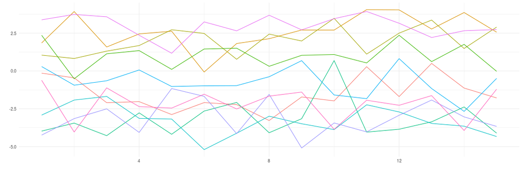

## I guess that’s good…

More to come!